# Assignment 5

Svadrut Kukunooru

#### Due Friday, October 15, 11:59 PM

### Baseball Preface

- The following code chunk will read in each of the data files from the 2021 major league baseball season and do some slight transformations.
- The code chunk has the argument `include = FALSE` set, so it will not appear in the knitted document.
- The first several problems use this data and ask you to use various `*_join()` functions to combine data from different files together.
- There are many columns with statistics that we will not use.
- Those needed for a particular problem will be described as needed.
- You do not need to be familiar with the rules of baseball or knowledgeable about the teams to solve the problems

#### File Descriptions

- The basic *player* data sets have one row for each player if the player played for a single team the entire season.
- If the player played for multiple teams, then there is one row for that player for each team that the player played for and an additional row with the combined statistics over the year.
  - The combined row has the variable `Tm` for team set to `TOT` for total
- The value *player* data sets have one row for each player
- Files with the word *pitching* contain statistics about the part of the game where a player in the role of a pitcher throws the ball toward the plate
- Files with the word *batting* contain statistics about the part of the game where a player in the role of a batter stands with a bat at the plate and reacts to the pitched ball.
- Most players in major league baseball are primarily either pitchers or position players, but some players will do both
  - In the National League, pitchers are in the lineup and so tend to bat much more often than in the American League where the pitcher is replaced by a *designated hitter* in the lineup.
  - Occasionally, a player who is primarily a position player will pitch
- The *team* and *standings* data files contain statistics aggregated over all players who played for that team.
- There are 30 major league baseball teams
  - There are 15 teams each in the American and National Leagues
  - Each League is divided into three divisions of five teams each with the names East, Central, and West
- The variable `Tm` for team is recorded differently in different files
  - The *player* data files variable `Tm` is a three-letter abbreviation for the team (or `TOT` for total).
  - The *team* and *standings* data files variable `Tm` is the full team name
  - Each full team name begins with a location (most often a city, but occasionally a state)
- The 2021 regular season ended on Sunday, October 3. Playoffs are currently under way.
- The only team from Wisconsin, the Milwaukee Brewers, are in the playoffs and begin a best-of-five series versus the Atlanta Braves on Friday, October 8.

### 1

The data sets `player_bat_basic` and `player_bat_value` contain summary statistics from every player that appeared as a batter in a major league baseball game. The data sets `player_pitch_basic` and `player_pitch_value` contain summary statistics from every player that appeared as a pitcher in a major league baseball game.

- The *value* data sets should have a single row per player.
- The *basic* data sets have a single row for most players, but players that appeared for more than one team have a single row for each team for which they appeared with an additional row for their combined batting or pitching statistics designated by the `Tm` variable having the value `TOT`
- As some players might have the same name, the column `ID` contains a unique identifier for each player

### (a)

Are there any players listed in one of `player_bat_basic` or `player_bat_value` but not the other? Describe any discrepancies you discover.

Write code using the function `anti_join()` to answer the question.

```r
notInValue <- anti_join(player_bat_basic, player_bat_value)
notInBasic <- anti_join(player_bat_value, player_bat_basic)
notInBasic
```

```
## # A tibble: 159 × 24
##    Name     ID       Age Tm        G    PA  Rbat Rbaser   Rdp Rfield  Rpos   RAA
##    <chr>    <chr>  <dbl> <chr> <dbl> <dbl> <dbl>  <dbl> <dbl>  <dbl> <dbl> <dbl>
##  1 Willy A… adame…    25 2TM     140   555    16     -1     0      1     7    23
##  2 Riley A… adams…    25 2TM      47   120     2      0     0     -2     2     1
##  3 Tyler A… ander…    31 2TM      18    40    -6      0     0      0     7     0
##  4 Matt An… andri…    31 2TM       5     0     0      0     0      0     0     0
##  5 Orlando… arcia…    26 2TM      36    89    -6      0     0      1     0    -5
##  6 Shawn A… armst…    30 2TM       5     0     0      0     0      0     0     0
##  7 Jake Ar… arrie…    35 2TM      24    30    -3      0     0      0     5     2
##  8 Javier … baezj…    28 2TM     138   547    13      3     0      6     6    28
##  9 Anthony… banda…    27 2TM      29     1     0      0     0      0     0     0
## 10 Jacob B… barne…    31 2TM      18     0     0      0     0      0     0     0
## # … with 149 more rows, and 12 more variables: WAA <dbl>, Rrep <dbl>,
## #   RAR <dbl>, WAR <dbl>, waaWL% <dbl>, 162WL% <dbl>, oWAR <dbl>, dWAR <dbl>,
## #   oRAR <dbl>, Salary <chr>, Acquired <chr>, Pos Summary <chr>
```

```r
notInValue
```

```
## # A tibble: 508 × 30
##    Name  ID      Age Tm    Lg        G    PA    AB     R     H  `2B`  `3B`    HR
##    <chr> <chr> <dbl> <chr> <chr> <dbl> <dbl> <dbl> <dbl> <dbl> <dbl> <dbl> <dbl>
##  1 Will… adam…    25 TOT   MLB     140   555   497    77   130    32     1    25
##  2 Will… adam…    25 TBR   AL       41   142   132    16    26     6     1     5
##  3 Will… adam…    25 MIL   NL       99   413   365    61   104    26     0    20
##  4 Rile… adam…    25 TOT   MLB      47   120    99    13    22     8     1     2
##  5 Rile… adam…    25 TOR   AL       12    30    28     2     3     2     0     0
##  6 Rile… adam…    25 WSN   NL       35    90    71    11    19     6     1     2
##  7 Shau… ande…    26 TOT   MLB       4     0     0     0     0     0     0     0
##  8 Tyle… ande…    31 TOT   MLB      18    40    39     1     4     0     0     1
##  9 Tyle… ande…    31 PIT   NL       17    37    37     1     4     0     0     1
## 10 Tyle… ande…    31 SEA   AL        1     3     2     0     0     0     0     0
## # … with 498 more rows, and 17 more variables: RBI <dbl>, SB <dbl>, CS <dbl>,
## #   BB <dbl>, SO <dbl>, BA <dbl>, OBP <dbl>, SLG <dbl>, OPS <dbl>, OPS+ <dbl>,
## #   TB <dbl>, GDP <dbl>, HBP <dbl>, SH <dbl>, SF <dbl>, IBB <dbl>,
## #   Pos Summary <chr>
```

```r
rm(notInBasic, notInValue)
```

There are 159 players who are in not in `player_bat_basic` and 508 players who are not in `player_bat_value`.

### (b)

Repeat for the files `player_pitch_basic` and `player_pitch_value`

```r
notInValue <- anti_join(player_pitch_basic, player_pitch_value)
notInBasic <- anti_join(player_pitch_value, player_pitch_basic)
notInBasic
```

```
## # A tibble: 111 × 25
##    Name    ID      Age Tm       IP     G    GS     R   RA9 RA9opp RA9def RA9role
##    <chr>   <chr> <dbl> <chr> <dbl> <dbl> <dbl> <dbl> <dbl>  <dbl>  <dbl>   <dbl>
##  1 Shaun … ande…    26 3TM    23.1    16     0    30 11.6    4.75   0.04   -0.23
##  2 Tyler … ande…    31 2TM   167      31    31    87  4.69   4.6   -0.04    0.22
##  3 Matt A… andr…    31 2TM    48.1    34     0    35  6.52   4.74   0.1    -0.31
##  4 Shawn … arms…    30 2TM    36      31     0    28  7      4.77   0.06   -0.31
##  5 Jake A… arri…    35 2TM    98.2    24    24    91  8.3    4.58   0.22    0.22
##  6 Anthon… band…    27 2TM    33.2    30     0    18  4.81   4.52   0.04   -0.29
##  7 Jacob … barn…    31 2TM    28.2    29     0    20  6.28   4.61   0.25   -0.3
##  8 Cam Be… bedr…    29 3TM    25      26     1    14  5.04   4.38  -0.26   -0.26
##  9 Jose B… berr…    27 2TM   192      32    32    83  3.89   4.67   0.19    0.22
## 10 Phil B… bick…    25 2TM    51.1    57     0    18  3.16   4.7    0.24   -0.31
## # … with 101 more rows, and 13 more variables: RA9extras <dbl>, PPFp <dbl>,
## #   RA9avg <dbl>, RAA <dbl>, WAA <dbl>, gmLI <dbl>, WAAadj <dbl>, WAR <dbl>,
## #   RAR <dbl>, waaWL% <dbl>, 162WL% <dbl>, Salary <chr>, Acquired <chr>
```

```r
notInValue
```

```
## # A tibble: 355 × 35
##    Name      ID       Age Tm    Lg        W     L `W-L%` ERA       G    GS    GF
##    <chr>     <chr>  <dbl> <chr> <chr> <dbl> <dbl>  <dbl> <chr> <dbl> <dbl> <dbl>
##  1 Shaun An… ander…    26 TOT   MLB       0     0 NA     8.49     16     0     6
##  2 Shaun An… ander…    26 TOT   AL        0     0 NA     9.16     11     0     5
##  3 Shaun An… ander…    26 MIN   AL        0     0 NA     9.35      4     0     0
##  4 Shaun An… ander…    26 BAL   AL        0     0 NA     9.00      7     0     5
##  5 Shaun An… ander…    26 SDP   NL        0     0 NA     5.79      5     0     1
##  6 Tyler An… ander…    31 TOT   MLB       7    11  0.389 4.53     31    31     0
##  7 Tyler An… ander…    31 PIT   NL        5     8  0.385 4.35     18    18     0
##  8 Tyler An… ander…    31 SEA   AL        2     3  0.4   4.81     13    13     0
##  9 Matt And… andri…    31 TOT   AL        2     3  0.4   5.21     34     0    13
## 10 Matt And… andri…    31 BOS   AL        2     3  0.4   6.03     26     0     7
## # … with 345 more rows, and 23 more variables: CG <dbl>, SHO <dbl>, SV <dbl>,
## #   IP <dbl>, H <dbl>, R <dbl>, ER <dbl>, HR <dbl>, BB <dbl>, IBB <dbl>,
## #   SO <dbl>, HBP <dbl>, BK <dbl>, WP <dbl>, BF <dbl>, ERA+ <dbl>, FIP <dbl>,
## #   WHIP <dbl>, H9 <dbl>, HR9 <dbl>, BB9 <dbl>, SO9 <dbl>, SO/W <dbl>
```

```r
rm(notInBasic, notInValue)
```

There are 111 players not in `player_pitch_basic` and 355 players not in `player_pitch_value`.

### 2

Create a data frame with one row for each team with the following variables:

- `Team` and `Abbr` from `abbr`
- `League` from the `Lg` variable of a *player* data set as matches `Abbr` matches `Tm`
- `Division` from the divisions data set
- `W` and `L` from `standings`
- `Pct` equal to `W/(W+L)`

Arrange the rows by division, and then from highest to lowest winning percentage within division. Print the entire table.

```r
DIVISIONS <- divisions %>% group_by(Tm) %>% arrange(Tm) %>% select(Division)
DIVISIONS
```

```
## # A tibble: 30 × 2
## # Groups:   Tm [30]
##    Tm                   Division
##    <chr>                <chr>
##  1 Arizona Diamondbacks NL West
##  2 Atlanta Braves       NL East
##  3 Baltimore Orioles    AL East
##  4 Boston Red Sox       AL East
##  5 Chicago Cubs         NL Central
##  6 Chicago White Sox    AL Central
##  7 Cincinnati Reds      NL Central
##  8 Cleveland Indians    AL Central
##  9 Colorado Rockies     NL West
## 10 Detroit Tigers       AL Central
## # … with 20 more rows
```

```r
abbr$Division <- DIVISIONS$Division
LG <- player_bat_basic %>% filter(duplicated(Tm) == FALSE) %>% select(Tm, Lg) %>% group_by(Tm) %>% arrange(Tm)
LG <- LG[-c(30),]
abbr$League <- LG$Lg

STANDINGS <- standings %>% arrange(Tm)
abbr$W <- standings$W
abbr$L <- standings$L
abbr$Pct <- (abbr$W/(abbr$W + abbr$L))
FINALQ1 <- abbr %>% arrange(Division)
print(FINALQ1)
```

```
## # A tibble: 30 × 7
##    Team               Abbr  Division   League     W     L   Pct
##    <chr>              <chr> <chr>      <chr>  <dbl> <dbl> <dbl>
##  1 Chicago White Sox  CHW   AL Central AL        93    69 0.574
##  2 Cleveland Indians  CLE   AL Central AL        92    70 0.568
##  3 Detroit Tigers     DET   AL Central AL        90    72 0.556
##  4 Kansas City Royals KCR   AL Central AL        88    73 0.547
##  5 Minnesota Twins    MIN   AL Central AL        79    83 0.488
##  6 Baltimore Orioles  BAL   AL East    AL       100    62 0.617
##  7 Boston Red Sox     BOS   AL East    AL        95    67 0.586
##  8 New York Yankees   NYY   AL East    AL        77    85 0.475
##  9 Tampa Bay Rays     TBR   AL East    AL        61   101 0.377
## 10 Toronto Blue Jays  TOR   AL East    AL        52   110 0.321
## # … with 20 more rows
```

```r
rm(DIVISIONS, LG, STANDINGS)
```

### 3

Using the table created in the previous problem, select the columns `Abbr`, `Division`, and add a new column named `Place` that takes the values from 1 to 5 from the teams with the highest to lowest winning percentages in each division. (Do not worry about dealing with ties.) Then, reshape this table to a wider format with `Place` as one column and the six division names as other column names with the team abbreviations sorted from first to last place within each division column making up the values of the table interior. Display the entire table.

```r
FINALQ2 <- data.frame(Place = c(5,4,3,2,1),
                 stringsAsFactors=FALSE)
```

```r
FINALQ1ABBRS <- FINALQ1 %>% select(Abbr, Division)
AL_CENTRAL <- FINALQ1ABBRS[1:5, ] %>%  select(Abbr)
AL_EAST <- FINALQ1ABBRS[6:10, ] %>% select(Abbr)
AL_WEST <- FINALQ1ABBRS[11:15, ] %>% select(Abbr)
NL_CENTRAL <- FINALQ1ABBRS[16:20, ] %>% select(Abbr)
NL_EAST <- FINALQ1ABBRS[21:25, ] %>% select(Abbr)
NL_WEST <- FINALQ1ABBRS[26:30, ] %>% select(Abbr)

FINALQ2 <- FINALQ2 %>% cbind(AL_CENTRAL) %>% cbind(AL_EAST) %>% cbind(AL_WEST) %>% cbind(NL_CENTRAL) %>% cbind(NL_EAST) %>% cbind(NL_WEST)
colnames(FINALQ2) <- c("Place", "AL Central", "AL East", "AL West", "NL Central", "NL East", "NL West")

FINALQ2
```

```
##   Place AL Central AL East AL West NL Central NL East NL West
## 1     5        CHW     BAL     HOU        CHC     ATL     ARI
## 2     4        CLE     BOS     LAA        CIN     MIA     COL
## 3     3        DET     NYY     OAK        MIL     NYM     LAD
## 4     2        KCR     TBR     SFG        PIT     PHI     SDP
## 5     1        MIN     TOR     TEX        STL     WSN     SEA
```

```r
rm(AL_CENTRAL, AL_EAST, AL_WEST, NL_CENTRAL, NL_EAST, NL_WEST, FINALQ1ABBRS)
```

### 4

This problem seeks to identify the best batters among players that are primarily pitchers. The variable `OPS` stands for on base percentage plus slugging percentage, an important baseball statistic for offensive production. High values refer to players that get on base often and hit for power.

Create a data frame with all players with at least 50 plate appearances as a batter (`PA >= 50`) and at least 50 innings pitched (`IP >= 50`). Use `ID` to join data from different tables. Retain the variables `Name`, `Tm`, `PA`, `BA`, `HR`, and `OPS` from the basic batting data set and the variables `ERA`, `SO`, and `IP` from the basic pitching data set. Sort the table in descending order of `OPS`. Display the first ten rows of the data set and all columns.

```r
Q3PITCH <- player_pitch_basic[(player_pitch_basic[,16]>50),] %>% select(ID, ERA, SO, IP)
Q3BAT <- player_bat_basic[(player_bat_basic[,7]>50),] %>% select(Name, ID, Tm, PA, BA, HR, OPS)
FINALQ3 <- inner_join(Q3BAT, Q3PITCH, by="ID") %>% arrange(desc(OPS)) %>% print(n = 10, width=Inf)
```

```
## # A tibble: 33 × 10
##    Name           ID        Tm       PA    BA    HR   OPS ERA      SO    IP
##    <chr>          <chr>     <chr> <dbl> <dbl> <dbl> <dbl> <chr> <dbl> <dbl>
##  1 Shohei Ohtani  ohtansh01 LAA     639 0.257    46 0.965 3.18    156 130.
##  2 German Marquez marquge01 COL      60 0.264     1 0.679 4.40    176 180
##  3 Max Fried      friedma01 ATL      67 0.273     0 0.649 3.04    158 165.
##  4 Jon Lester     lestejo01 TOT      51 0.167     1 0.471 4.71     91 141.
##  5 Jon Lester     lestejo01 TOT      51 0.167     1 0.471 5.02     51  75.1
##  6 Jon Lester     lestejo01 TOT      51 0.167     1 0.471 4.36     40  66
##  7 Wade Miley     mileywa01 CIN      59 0.185     0 0.469 3.37    125 163
##  8 Julio Urias    uriasju01 LAD      70 0.203     0 0.454 2.96    195 185.
##  9 Logan Webb     webblo01  SFG      53 0.13      1 0.449 3.03    158 148.
## 10 Aaron Nola     nolaaa01  PHI      63 0.143     0 0.416 4.63    223 180.
## # … with 23 more rows
```

```r
rm(Q3PITCH, Q3BAT)
```

Make a boxplot of the `OPS` variable. Describe any notable features in this plot.

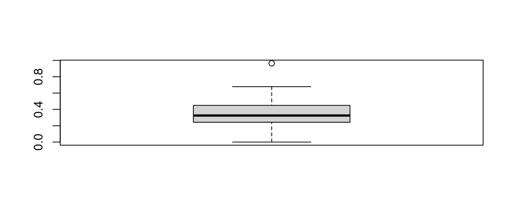

```r
boxplot(FINALQ3$OPS)
```

There is one outlier that has a nearly perfect OPS, but everybody else’s OPS ranges from nearly 0.0 to 0.7.

### 5

Read in the `obesity.csv` file. Create a subset of the obesity data such that:

- there are no rows from children aged 5–17;
- retain a zip code only if there is no missing obesity data for all four age groups for each sex
  - there must be eight non-missing data observations per retained zip code
  - you may find it useful to create a data summary by zip code with the number of adult rows without missing data first to identify the zip codes to keep
- filter out zip/sex/age cohorts with missing obesity data
- calculate the estimated number of adults in the population in each remaining zip code and sex from the age groups where we have obesity data who are obese
- calculate the estimated proportion of adults in each zip code and sex (for age groups with obesity data) who are obese

The resulting data frame should have the following columns of data.

- `zip` = zip code
- `sex` = sex (male or female)
- `adult_n` = estimated # of adults (by zip and sex)
- `obese_n` = estimated # of obese adults (by zip and sex)
- `obese_p` = estimated proportion of obese adults (by zip and sex)

```r
obesity = read_csv("../../data/obesity.csv")
obesity <- obesity[!obesity$age == "05-17",]
obesity <- obesity[!is.na(obesity$obese),]
ZIPS2KILL <- obesity %>% group_by(zip) %>% summarise(isThereData = n())
ZIPS2KILL <- ZIPS2KILL[ZIPS2KILL$isThereData != 8,]
ZIPS2KILL <- ZIPS2KILL$zip
obesity <- obesity[!obesity$zip %in% ZIPS2KILL, ]
FINALQ4 <- obesity %>% group_by(zip, sex) %>% summarise(adult_n = sum(n), obese_n = sum(obese), obese_p = obese_n/adult_n)
FINALQ4
```

```
## # A tibble: 612 × 5
## # Groups:   zip [306]
##      zip sex    adult_n obese_n obese_p
##    <dbl> <chr>    <dbl>   <dbl>   <dbl>
##  1 53002 female     549     211   0.384
##  2 53002 male       475     201   0.423
##  3 53005 female    2965     789   0.266
##  4 53005 male      2211     760   0.344
##  5 53010 female    1349     550   0.408
##  6 53010 male      1132     507   0.448
##  7 53012 female    2695     815   0.302
##  8 53012 male      2234     852   0.381
##  9 53013 female     344     142   0.413
## 10 53013 male       279     116   0.416
## # … with 602 more rows
```

### 6

Read in the `education.csv` data frame and reshape it so that there is a single row for each zip code and sex (so, two rows per zip code) using the `pivot_longer()` function. After the transformation, you should have columns

- `zip` = zip code
- `sex` = sex (male or female)
- `pct_bach` = % adults (aged 25+, of the given sex by zip) with at least a bachelors degree

This action will require both reshaping data and transforming the values and column names.

```r
education = read_csv("../../data/education.csv")
colnames(education) = c("zip", "Male", "Female")
education <- education %>% pivot_longer(c(Female, Male), names_to = "sex", values_to = "pct_bach")
```

Print out all columns of the first ten rows of the education data frame.

```r
print(education)
```

```
## # A tibble: 1,552 × 3
##      zip sex    pct_bach
##    <dbl> <chr>     <dbl>
##  1 53001 Female     23
##  2 53001 Male       13
##  3 53002 Female     25.4
##  4 53002 Male       16.2
##  5 53003 Female      9.4
##  6 53003 Male        6.8
##  7 53004 Female     26.8
##  8 53004 Male       23.3
##  9 53005 Female     53.9
## 10 53005 Male       55.6
## # … with 1,542 more rows
```

### 7

Join the two data sets together by adding the `pct_bach` column to the data set from problem 5.

```r
education <- education[!education$zip %in% ZIPS2KILL,]
education <- education[education$zip %in% FINALQ4$zip,]
FINALQ4$pct_bach <- education$pct_bach
```

Using the joined data set and the adult population, calculate the statewide percentages of men and women aged 25 and older with a bachelors degree. (Ignore the issue that the population totals include adults aged 18-24. This has minimal effect on the calculations as the key factor is different education rates by relative zip code populations, not absolute populations.) Display the numerator and denominator for each percentage calculation as part of your solution.

```r
FEMALE <- subset(FINALQ4, FINALQ4$sex == "female")
MALE <- subset(FINALQ4, FINALQ4$sex == "male")
malepct <- mean(MALE$pct_bach)
femalepct <- mean(FEMALE$pct_bach)
rm(MALE, FEMALE)
```

The male percentage is 23.966%, and the female percentage is 26.624%.

### 8

Make a scatter plot with one point per zip code and sex that displays the *percentage* of a zip code aged 25+ with a bachelor’s degree on the x-axis and the *percentage* obese on the y axis.  
- Use different colors for each sex and add a trend line or curve for each sex.  
- Create appropriate labels and titles for the plot.

[figure not shown]

```r
ggplot(data = FINALQ4) +
  geom_point(mapping = aes(x = pct_bach, y = obese_p, color = sex)) + ggtitle("Obesity Percentage vs. Bachelor's Percentage, By Sex and Zip Code") + ylab("Obese Percentage") + xlab("Bachelor's Percentage") +   geom_smooth(mapping = aes(x = pct_bach, y = obese_p, color=sex))
```

Comment on patterns in the plot of the data. What is the evident relationship between obesity and obtaining a college education?